# Final Exam

#### Plot 3: Total fat vs calories

```r
cor(fastfoodclean$total_fat, fastfoodclean$calories)
```

```
## [1] 0.8992933
```

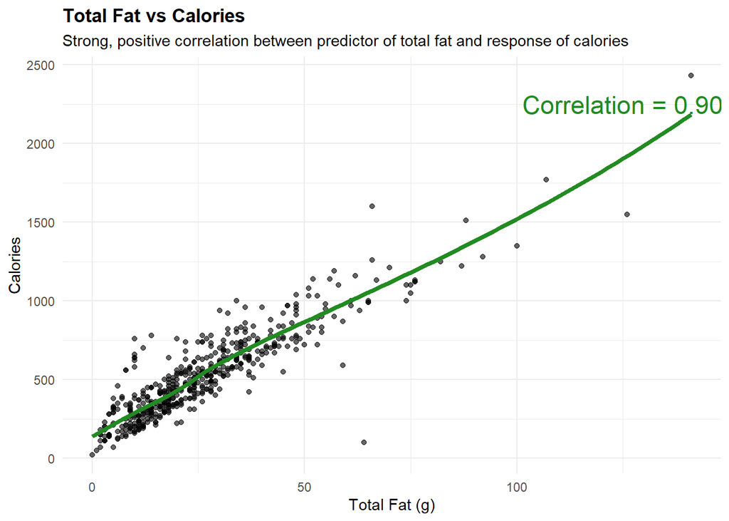

```r
totalfat_calories <- ggplot(fastfoodclean, aes(x = total_fat, y = calories)) +
  geom_point(alpha = 0.6) +
  geom_smooth(se = FALSE, color = "forestgreen", linewidth = 1.5) +
  annotate("text", x = 125, y = 2250, label = "Correlation = 0.90", size = 6, color = "forestgreen") +
  labs(title = "Total Fat vs Calories",
       subtitle = "Strong, positive correlation between predictor of total fat and response of calories",
       x = "Total Fat (g)",
       y = "Calories") +
  theme_minimal() +
  theme(plot.title = element_text(face = "bold"))

totalfat_calories
```

The plot above is a scatterplot between total fat and calories with a trend line on top. There is a strong, positive correlation between the predictor of total fat and response of calories at about 0.90.

#### Plot 4: Cholesterol by Calorie Class

```r
summarystats <- fastfoodclean |>
  group_by(calorie_class) |>
  summarise(mean_chol = mean(cholesterol, na.rm = TRUE),
            med_chol = median(cholesterol, na.rm = TRUE))
summarystats
```

```
## # A tibble: 2 × 3
##   calorie_class mean_chol med_chol
##   <fct>             <dbl>    <dbl>
## 1 Low                41.4       40
## 2 High              104.        90
```

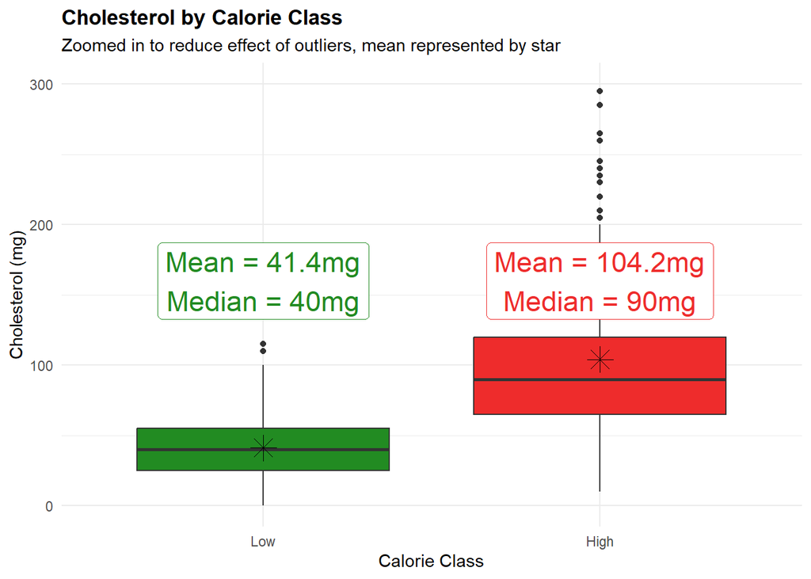

```r
cholesterol_calories <- ggplot(fastfoodclean, aes(x = calorie_class, y = cholesterol, fill = calorie_class)) +
  geom_boxplot() +
  stat_summary(fun = mean, geom= "point", shape = 8, size = 5) +
  scale_fill_manual(values = c("Low" = "forestgreen", "High" = "firebrick2")) +
  coord_cartesian(ylim = c(0,300)) +
    annotate("label", x = 1, y = 160, label = "Mean = 41.4mg\nMedian = 40mg", size =  6, color = "forestgreen") +
  annotate("label", x = 2, y = 160, label = "Mean = 104.2mg\nMedian = 90mg", size =  6, color = "firebrick2") +
  labs(
    title = "Cholesterol by Calorie Class",
    subtitle = "Zoomed in to reduce effect of outliers, mean represented by star",
    x = "Calorie Class",
    y = "Cholesterol (mg)") +
  theme_minimal() +
  theme(plot.title = element_text(face = "bold"),
        legend.position = "none")

cholesterol_calories
```

The box plot above shows the relationship between cholesterol and calorie class. For the low calorie class (less than 500), the cholesterol is much lower on average compared to the high calorie class (>= 500).

#### Plot 5: Sodium vs Calories

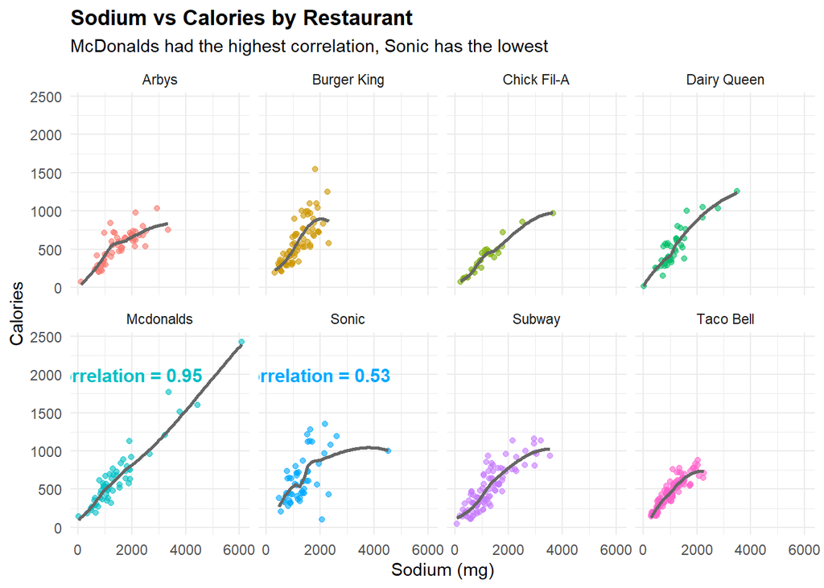

```r
sodium_corr <- fastfoodclean |>
  group_by(restaurant) |>
  summarise(corr = cor(sodium, calories))

corr_labels <- data.frame(
  restaurant = c("Mcdonalds", "Sonic"),
  label = c("Correlation = 0.95", "Correlation = 0.53"))

sodium_calories <- ggplot(fastfoodclean, aes(x = sodium, y = calories, color = restaurant)) +
  geom_point(alpha = 0.6) +
  geom_smooth(se = FALSE, color = "gray40") +
  facet_wrap(~restaurant, ncol = 4) +
geom_text(
    data = corr_labels, aes(x = 1750, y = 2000, label = label),size = 4, fontface = "bold") +
  labs(
    title = "Sodium vs Calories by Restaurant",
    subtitle = "McDonalds had the highest correlation, Sonic has the lowest",
    x = "Sodium (mg)",
    y = "Calories") +
  theme_minimal() +
  theme(plot.title = element_text(face = "bold"),
        legend.position = "none")

sodium_calories
```

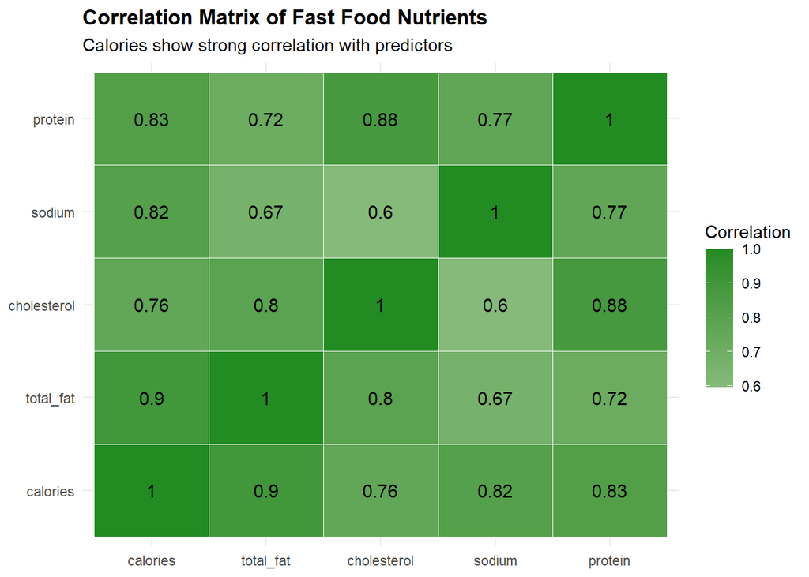

```r
corr_df <- cor(
  fastfoodclean |>
    select(calories, total_fat, cholesterol, sodium, protein))

corr_long <- as.data.frame(as.table(corr_df))

correlation_matrix <- ggplot(corr_long, aes(x = Var1, y = Var2, fill = Freq)) +
  geom_tile(color = "white") +
  geom_text(aes(label = round(Freq, 2)), size = 4) +
  scale_fill_gradient2(
    low = "firebrick2", mid = "white", high = "forestgreen",
    midpoint = 0, name = "Correlation"
  ) +
  labs(title = "Correlation Matrix of Fast Food Nutrients",
       subtitle = "Calories show strong correlation with predictors") +
  theme_minimal() +
  theme(
    axis.title = element_blank(),
    plot.title = element_text(face = "bold"))

correlation_matrix
```

The above plot is a correlation matrix between calories and the predictors. There is a strong correlation between the calories and the predictors but also between the predictors themselves.

#### Dashboard

[figure not shown]

```r
dashboard <-
  (calorie_distribution | calorie_restaurant) /
  (totalfat_calories | cholesterol_calories) /
  (sodium_calories | correlation_matrix) +
  plot_layout(heights = c(1, 1, 1)) +
  plot_annotation(
    title = "Fast Food Nutrition Dashboard Analysis",
    subtitle = "Exploring the key relationships between calories and predictors across restaurants",
    caption = "Source: fastfoodnutrition.com & TidyTuesday",
    theme = theme(
      plot.title = element_text(size = 24, face = "bold", hjust = 0.5),
      plot.subtitle = element_text(size = 16, hjust = 0.5),
      plot.caption = element_text(size = 14)))

dashboard
```

```r
ggsave("dashboard.png", dashboard, width = 60, height = 35, units = "cm")
```

The above code created my dashboard with all six plots. I included a title, subtitle and caption to convey more information and made sure the size looked good.

#### Save all plots as PNG

```r
ggsave("plot1_calorie_distribution.png", calorie_distribution, width = 40, height = 20, units = "cm")
ggsave("plot2_calorie_restaurant.png", calorie_restaurant, width = 40, height = 20, units = "cm")
ggsave("plot3_totalfat_calories.png", totalfat_calories, width = 40, height = 20, units = "cm")
ggsave("plot4_cholesterol_calories.png", cholesterol_calories, width = 40, height = 20, units = "cm")
ggsave("plot5_sodium_calories.png", sodium_calories, width = 40, height = 20, units = "cm")
ggsave("plot6_correlation_matrix.png", correlation_matrix, width = 40, height = 20, units = "cm")
```

This code saved all of the graphs into png images.

### Predictive Modeling

#### Model 1: Linear Regression (Full Model)

```r
ctrl <- trainControl(method = "cv", number = 5)

set.seed(512)

lm_full <- train(calories ~ restaurant + total_fat + cholesterol + sodium + protein,
                 data = fastfoodclean,
                 method = "lm",
                 trControl = ctrl)
```

This model uses all predictors to estimate the linear relationships between calories and the nutrient predictors. It is used as a baseline model.

#### Model 2: Linear Regression (Subset)

```r
set.seed(512)

lm_subset <- train(calories ~ total_fat + protein + sodium,
                   data = fastfoodclean,
                   method = "lm",
                   trControl = ctrl)
```

This model uses the three strongest predictors based on the correlation matrix. This is used to test whether the reduced model can maintain the same accuracy as the full model.

#### Model 3: Regression Tree

```r
set.seed(512)

tree_model <- train(calories ~ restaurant + total_fat + cholesterol + sodium + protein,
                 data = fastfoodclean,
                 method = "rpart",
                 trControl = ctrl)
```

This model uses a decision tree to capture relationships between the nutritional predictors and calorie output. It automatically splits the data which is useful for identifying how different levels influence the calories.

#### Model 4: Random Forest

```r
set.seed(512)

rf_model <- train(calories ~ restaurant + total_fat + cholesterol + sodium + protein,
                 data = fastfoodclean,
                 method = "rf",
                 trControl = ctrl,
                 importance = TRUE)
```

The random forest model improved predictive performance compared to the regression tree because it builds multiple decision trees on different subsets of data. This reduces overfitting and improves the predictive power of the model. It is good for this because the predictors are correlated and helps capture the relationships.

#### Model 5: Interaction Linear Regression

```r
set.seed(512)

lm_interaction <- train(calories ~ total_fat * sodium + cholesterol + protein + restaurant,
                 data = fastfoodclean,
                 method = "lm",
                 trControl = ctrl)
```

This model is a continuation of linear regression but it includes the interaction between total fat and sodium. This is important because a lot of times in nutrition, the variables depend on each other.

### Model Comparison

```r
models <- resamples(list(
  LM_full = lm_full,
  LM_subset = lm_subset,
  Tree = tree_model,
  RandomForest = rf_model,
  LM_interaction = lm_interaction))

summary(models)
```

```
##
## Call:
## summary.resamples(object = models)
##
## Models: LM_full, LM_subset, Tree, RandomForest, LM_interaction
## Number of resamples: 5
##
## MAE
##                     Min.   1st Qu.    Median      Mean   3rd Qu.      Max. NA's
## LM_full         44.28461  46.87010  47.70495  49.85471  51.65927  58.75463    0
## LM_subset       51.47487  56.08122  58.98046  58.92376  60.24596  67.83630    0
## Tree           110.37878 117.27083 120.61144 121.33230 124.64386 133.75659    0
## RandomForest    47.03822  48.42746  51.57978  53.60033  56.44207  64.51412    0
## LM_interaction  41.08988  43.58965  44.47455  47.10928  48.39603  57.99632    0
##
## RMSE
##                     Min.   1st Qu.    Median      Mean   3rd Qu.     Max. NA's
## LM_full         58.34776  62.77815  64.63873  75.53158  76.94317 114.9501    0
## LM_subset       67.75840  74.46037  75.65398  83.86229  82.78998 118.6487    0
## Tree           142.67094 148.41928 164.18791 164.40172 180.14628 186.5842    0
## RandomForest    63.13469  74.56543  78.37778  88.22653 105.28639 119.7684    0
## LM_interaction  58.18501  58.48145  61.05082  71.92953  66.88595 115.0444    0
##
## Rsquared
##                     Min.   1st Qu.    Median      Mean   3rd Qu.      Max. NA's
## LM_full        0.8563015 0.9399819 0.9415907 0.9309950 0.9568245 0.9602767    0
## LM_subset      0.8454845 0.9091538 0.9166869 0.9112987 0.9410614 0.9441066    0
## Tree           0.6198260 0.6409876 0.6805179 0.6707899 0.6818920 0.7307260    0
## RandomForest   0.8406365 0.8978780 0.9245303 0.9063690 0.9274904 0.9413099    0
## LM_interaction 0.8581234 0.9472841 0.9513740 0.9344904 0.9565672 0.9591033    0
```

```r
rmse_plot <- ggplot(models, metric="RMSE") +
  labs(title = "Comparison of Models RMSE Values") +
  theme_minimal()

rsquared_plot <- ggplot(models, metric="Rsquared") +
labs(title = "Comparison of Models Rsquared Values") +
  theme_minimal()
```

The above code creates an output that summarizes the MAE, RMSE, and Rsquared values for the models. For RMSE, the linear model with interaction (Model 5) performed the best with a value of 71.9, next was the full linear model at 75.5. The worst model was the tree with a value of 164.4 For rsquared, the linear model with interaction performed the best with 93.4% of the variability being explained and the wort was the tree at 67.1%.

Based on these results, the interaction model performs the best overall because it has the lowest RMSE (71.9) and highest rsquared (0.934) among the models. This suggests that the calorie content in fast food is largely explained by linear relationships between all of the predictors and with interaction effects. The full linear performs similarly with a RMSE of 75.5 and rsquared of 0.93.The worst model by far is the regression tree with a high RMSE value of 164.4 and low rsquared of 0.671. This indicated that it has poor predictive performance. Overall, the linear regression model with interaction performs the best because in nutrition there are relationships between the variables and they rely on each other.

Although the interaction model performed best, it’s improvement over the full linear model is very small. This suggests that adding complexity doesn’t add much in return. There can be better models out there that I did not test such as KNN or a different subset of predictors. This model also doesn’t capture the nonlinear effects that could occur in this situation. There also is evidence of mulitcollinearity in this dataset.

These results suggest that calorie content in fast food can be predicted using total_fat, sodium, cholesterol, protein, and the restaurant. There is a strong linear interaction between the predictors and response which shows that calorie content is largely driven by linear relationships. However, the prediction error shows that other additional factors could also influence this. These models provide useful estimates but there are other factors that contribute to the calorie content.

#### Save comparison plots

```r
ggsave("rmse_plot.png", rmse_plot, width = 40, height = 20, units = "cm")
ggsave("rsquared_plot.png", rsquared_plot, width = 40, height = 20, units = "cm")
```